# Diabetes Patient-Hospital Outcome Classification

Globant Data Science Fit

Andres Felipe Tellez

set.seed(2022)

Metodología Implementada - CRISP-DM

#### **1. Business understanding**

The data are submitted on behalf of the Center for Clinical and Translational Research, Virginia Commonwealth University and it represents 10 years (1999-2008) of clinical care at 130 US hospitals and integrated delivery networks. It includes over 50features representing patient and hospital outcomes.

Information regarding:

- Hospital admission
- Diabetics encounter
- The length of stay was at least 1 day and at most 14 days
- Laboratory tests were performed
- Medications were administered

Objectives: Classify a patient-hospital outcome and to cluster them aiming at finding patterns that give a distinct insight.

Current situation: The data contains such attributes as patient number, race, gender, age, admission type, time in hospital, medical specialty of admitting physician, number of lab test performed, HbA1c test result, diagnosis, number of medication, diabetic medications, number of outpatient, inpatient, and emergency visits in the year before the hospitalization, etc.

#### **2. Data understanding**

Importar datos:

```r
diabetic_data <- read.csv("~/dataset_diabetes/diabetic_data.csv", na.strings="?", stringsAsFactors=TRUE)
```

Asimismo, vale la pena asegurarse de que el formato de las variables sea leido correctamente. Por esto, se efectuó el suiguiente código para realizar los cambios necesarios a ciertas variables que se leian como textos cuando realmente se leen como numeros.

```r
diabetic_data$diag_1=as.numeric(diabetic_data$diag_1)
diabetic_data$diag_2=as.numeric(diabetic_data$diag_2)
diabetic_data$diag_3=as.numeric(diabetic_data$diag_3)
```

Se procede a hacer la separación de datos en dos sets: training y test. Para esto se necesita conocer dos parametros básicos sobre los datos: observaciones y variables.

```r
n = dim(diabetic_data)[1] #Number of observations
p = dim(diabetic_data)[2] - 1 #Number of predictors
```

Con esto en mente, se crean los números de las filas que seran test y el número de filas que seran para el train. La proporción escogida fue de 0,7 para training y 0,3 para test.

```r
indicesTrain = sample(1:n, round(n*0.7, digits = 0))
indicesTest = c(1:n)[-indicesTrain]

xTest = data.frame(diabetic_data[indicesTest,1:p])
xTrain = data.frame(diabetic_data[indicesTrain,1:p])

yTrain = data.frame(diabetic_data[indicesTrain,p+1])
yTest = data.frame(diabetic_data[indicesTest,p+1])
```

#### **2.1 Estadisticas Descriptivas**

#### **2.2 Tipos de datos**

Pasamos a la exploración de los datos. Partimos estudianto a las variables del set de datos. Con la siguiente función veo el tipo de datos con el que se va a trabajar. En este proceso es cuando me di cuenta que diag_# me lo leía como factor y no como número y por eso se hizo la corrección arriba.

```r
str(diabetic_data)
```

```
'data.frame':   101766 obs. of  50 variables:
 $ encounter_id            : int  2278392 149190 64410 500364 16680 35754 55842 63768 12522 15738 ...
 $ patient_nbr             : int  8222157 55629189 86047875 82442376 42519267 82637451 84259809 114882984 48330783 63555939 ...
 $ race                    : Factor w/ 5 levels "AfricanAmerican",..: 3 3 1 3 3 3 3 3 3 3 ...
 $ gender                  : Factor w/ 3 levels "Female","Male",..: 1 1 1 2 2 2 2 2 1 1 ...
 $ age                     : Factor w/ 10 levels "[0-10)","[10-20)",..: 1 2 3 4 5 6 7 8 9 10 ...
 $ weight                  : Factor w/ 9 levels "[0-25)","[100-125)",..: NA NA NA NA NA NA NA NA NA NA ...
 $ admission_type_id       : int  6 1 1 1 1 2 3 1 2 3 ...
 $ discharge_disposition_id: int  25 1 1 1 1 1 1 1 1 3 ...
 $ admission_source_id     : int  1 7 7 7 7 2 2 7 4 4 ...
 $ time_in_hospital        : int  1 3 2 2 1 3 4 5 13 12 ...
 $ payer_code              : Factor w/ 17 levels "BC","CH","CM",..: NA NA NA NA NA NA NA NA NA NA ...
 $ medical_specialty       : Factor w/ 72 levels "AllergyandImmunology",..: 38 NA NA NA NA NA NA NA NA 19 ...
 $ num_lab_procedures      : int  41 59 11 44 51 31 70 73 68 33 ...
 $ num_procedures          : int  0 0 5 1 0 6 1 0 2 3 ...
```

[output cut: 36 more lines]

#### **2.3 Data exploration**

**Histograma:**

Si bien hay tres clases y estas no tienen el mismo numero de observaciones, no se denota la necesidad de hacer un tratamiento de clases imbalanceadas pues hay una buena representacion de cada clase en la muestra de datos.

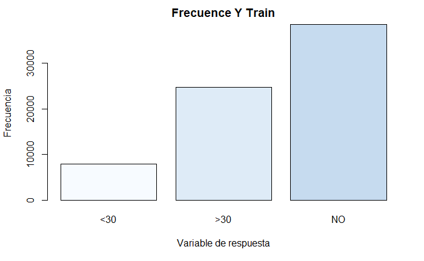

```r
freq_y_train = table(yTrain)
barplot(freq_y_train, col = blues9, main = "Frecuence Y Train", xlab = "Variable de respuesta", ylab = "Frecuencia")
```

**Correlacion:**

Asimismo, vale la pena ver la correlación entre variables. Especificamnete ver si hay información redundante entre los datos. Su importancia radica en que dependiendo de esto se puede escoger de forma más inteligente el modelo que se va a usar.

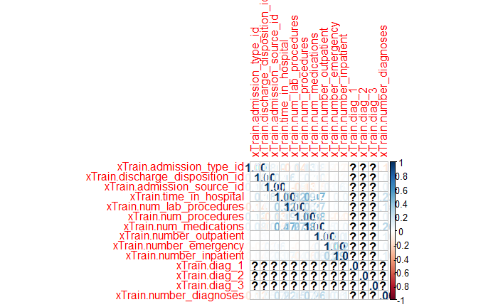

```r
library(corrplot)
M = data.frame(xTrain$admission_type_id, xTrain$discharge_disposition_id, xTrain$admission_source_id,
               xTrain$time_in_hospital, xTrain$num_lab_procedures, xTrain$num_procedures, xTrain$num_medications,
               xTrain$number_outpatient, xTrain$number_emergency, xTrain$number_inpatient, xTrain$diag_1,
               xTrain$diag_2, xTrain$diag_3, xTrain$number_diagnoses)
M_cor = cor(M)
corrplot(M_cor, method = 'number') # colorful number
```

Las dos variables que presentan la mayor correlacion positiva son dias en el hospital y numero de medicamentos suministrados

**a. Grafícas**

Preparo el panel, de modo que, pueda tener una visualización de múltiples grafícas.

[figure not shown]

[figure not shown]

[figure not shown]

[figure not shown]

[figure not shown]

[figure not shown]

[figure not shown]

[figure not shown]

[figure not shown]

**Box plots**

Si bien hay muchas variables cuyas clases (cajas) se sobreponen, se denota que hay una clara variabilidad entre los datos, de modo que, hay indicios de que hay varias variables significativas. También se denotan datos atipicos, por lo que se recomiendan usar metodos para eliminarlos.

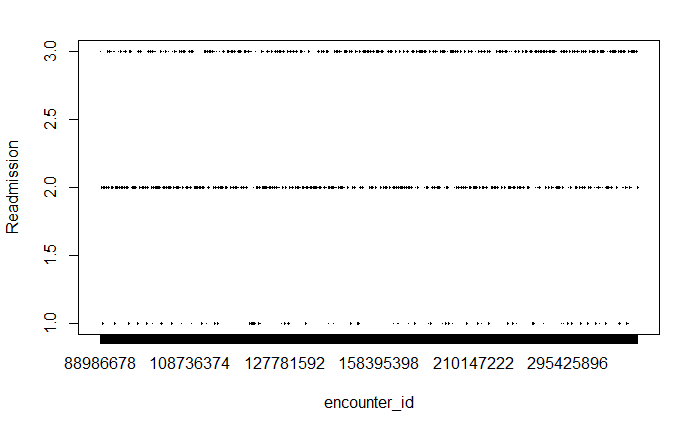

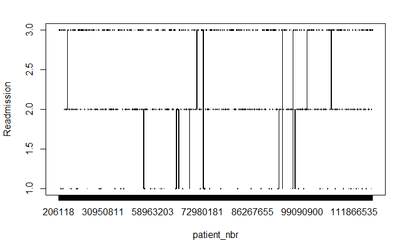

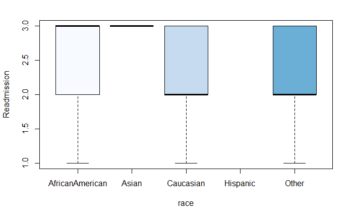

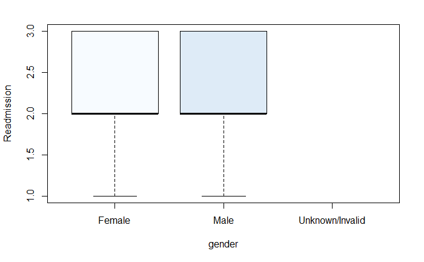

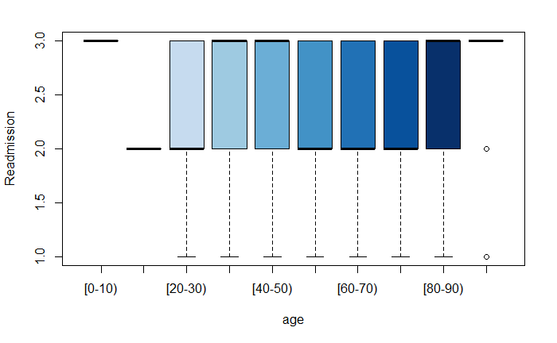

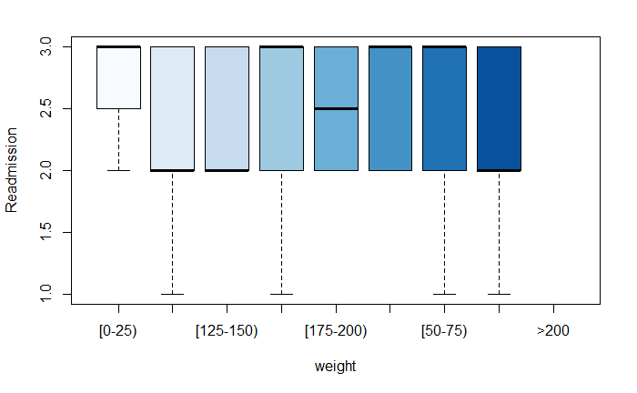

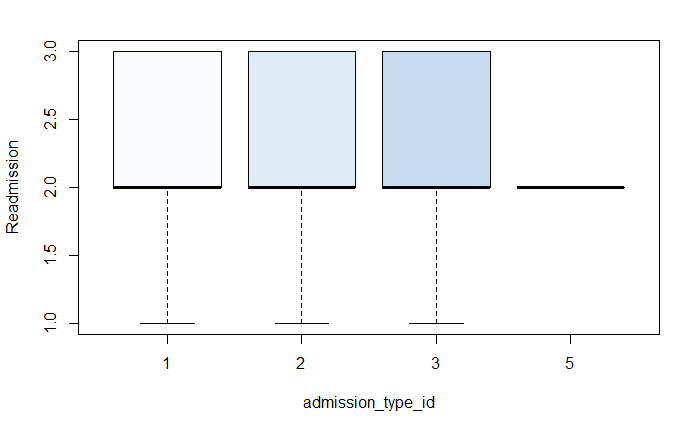

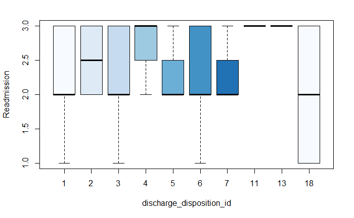

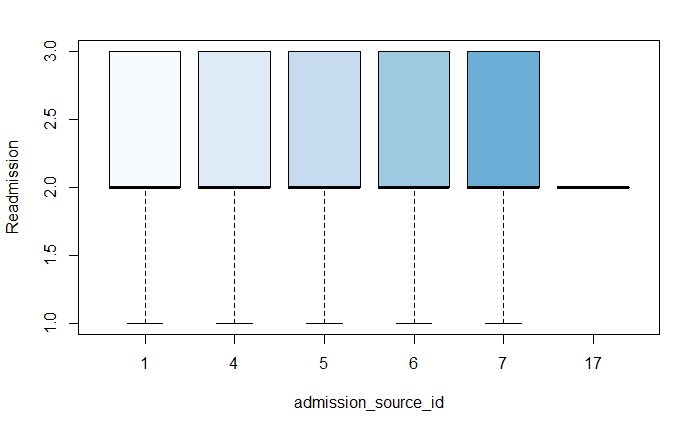

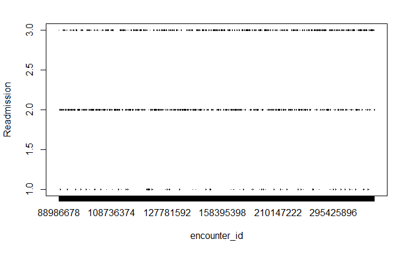

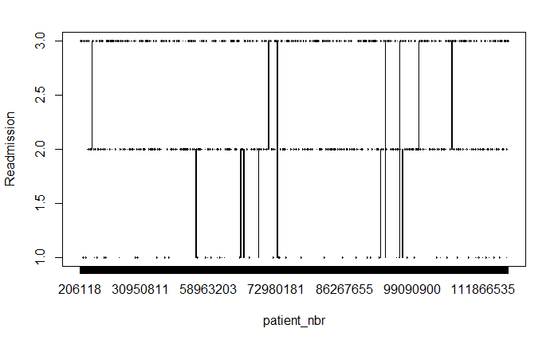

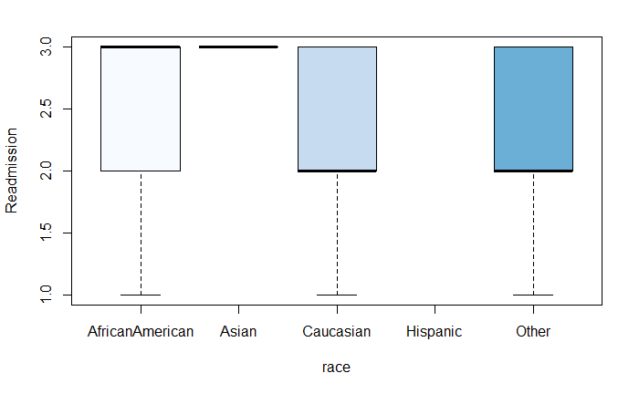

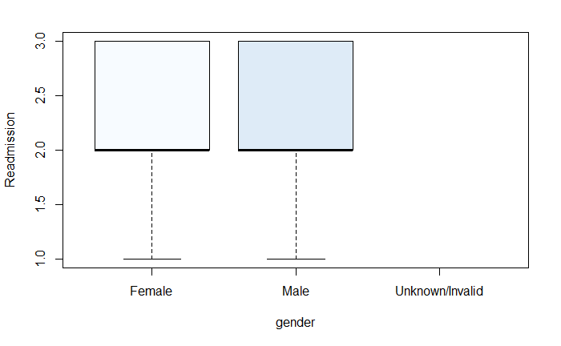

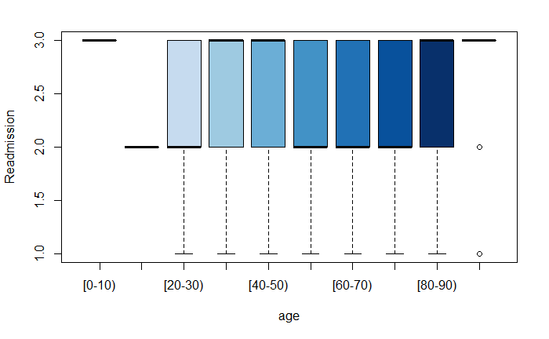

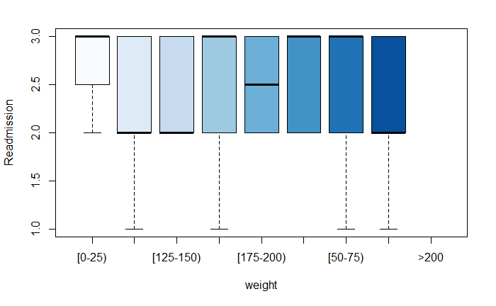

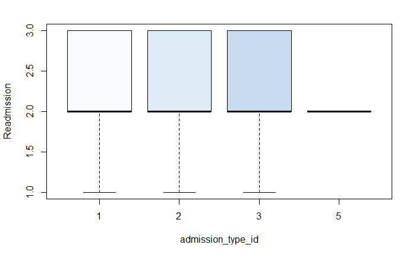

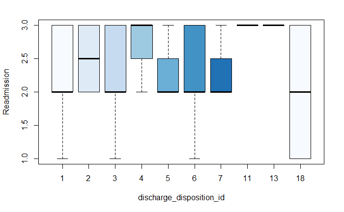

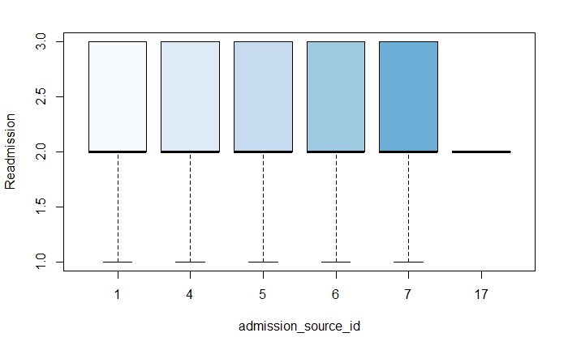

```r
for(i in 1:9){
  boxplot(M$diabetic_data.indicesTrain..p...1.~M[,i], xlab = colnames(M)[i], ylab = "Readmission", col= blues9)
}

for(i in 1:9){
  boxplot(M$diabetic_data.indicesTrain..p...1.~M[,i], xlab = colnames(M)[i], ylab = "Readmission", col= blues9)
}
```